# Unsupervised Learning: Trade&Ahead

**Marks: 60**

## Context

The stock market has consistently proven to be a good place to invest in and save for the future. There are a lot of compelling reasons to invest in stocks. It can help in fighting inflation, create wealth, and also provides some tax benefits. Good steady returns on investments over a long period of time can also grow a lot more than seems possible. Also, thanks to the power of compound interest, the earlier one starts investing, the larger the corpus one can have for retirement. Overall, investing in stocks can help meet life's financial aspirations.

It is important to maintain a diversified portfolio when investing in stocks in order to maximise earnings under any market condition. Having a diversified portfolio tends to yield higher returns and face lower risk by tempering potential losses when the market is down. It is often easy to get lost in a sea of financial metrics to analyze while determining the worth of a stock, and doing the same for a multitude of stocks to identify the right picks for an individual can be a tedious task. By doing a cluster analysis, one can identify stocks that exhibit similar characteristics and ones which exhibit minimum correlation. This will help investors better analyze stocks across different market segments and help protect against risks that could make the portfolio vulnerable to losses.

## Objective

Trade&Ahead is a financial consultancy firm who provide their customers with personalized investment strategies. They have hired you as a Data Scientist and provided you with data comprising stock price and some financial indicators for a few companies listed under the New York Stock Exchange. They have assigned you the tasks of analyzing the data, grouping the stocks based on the attributes provided, and sharing insights about the characteristics of each group.

### Data Dictionary

- Ticker Symbol: An abbreviation used to uniquely identify publicly traded shares of a particular stock on a particular stock market
- Company: Name of the company
- GICS Sector: The specific economic sector assigned to a company by the Global Industry Classification Standard (GICS) that best defines its business operations
- GICS Sub Industry: The specific sub-industry group assigned to a company by the Global Industry Classification Standard (GICS) that best defines its business operations
- Current Price: Current stock price in dollars
- Price Change: Percentage change in the stock price in 13 weeks
- Volatility: Standard deviation of the stock price over the past 13 weeks
- ROE: A measure of financial performance calculated by dividing net income by shareholders' equity (shareholders' equity is equal to a company's assets minus its debt)
- Cash Ratio: The ratio of a company's total reserves of cash and cash equivalents to its total current liabilities
- Net Cash Flow: The difference between a company's cash inflows and outflows (in dollars)
- Net Income: Revenues minus expenses, interest, and taxes (in dollars)
- Earnings Per Share: Company's net profit divided by the number of common shares it has outstanding (in dollars)
- Estimated Shares Outstanding: Company's stock currently held by all its shareholders
- P/E Ratio: Ratio of the company's current stock price to the earnings per share
- P/B Ratio: Ratio of the company's stock price per share by its book value per share (book value of a company is the net difference between that company's total assets and total liabilities)

## Importing necessary libraries and data

```python
# Libraries to help with reading and manipulating data
import numpy as np
import pandas as pd

# Libraries to help with data visualization
import matplotlib.pyplot as plt
import seaborn as sns

# to compute distances
from scipy.spatial.distance import cdist
from scipy import stats

# to perform k-means clustering and compute silhouette scores
from sklearn.cluster import KMeans
from sklearn.metrics import silhouette_score

# to visualize the elbow curve and silhouette scores
from yellowbrick.cluster import KElbowVisualizer, SilhouetteVisualizer

from scipy.spatial.distance import pdist

# to perform hierarchical clustering, compute cophenetic correlation, and create dendrograms
from sklearn.cluster import AgglomerativeClustering
from scipy.cluster.hierarchy import dendrogram, linkage, cophenet

# to perform PCA
from sklearn.decomposition import PCA

# To suppress the warnings
import warnings
warnings.filterwarnings("ignore")
```

## Data Overview

- Observations
- Sanity checks

```python
stock_data = pd.read_csv('stock_data.csv')
```

```python
stock_data.isna().sum()
```

```
Ticker Symbol                   0
Security                        0
GICS Sector                     0
GICS Sub Industry               0
Current Price                   0
Price Change                    0
Volatility                      0
ROE                             0
Cash Ratio                      0
Net Cash Flow                   0
Net Income                      0
Earnings Per Share              0
Estimated Shares Outstanding    0
P/E Ratio                       0
P/B Ratio                       0
dtype: int64
```

```python
stock_data = stock_data.dropna()
```

```python
stock_data.info()
```

```
<class 'pandas.core.frame.DataFrame'>
Int64Index: 340 entries, 0 to 339
Data columns (total 15 columns):
 #   Column                        Non-Null Count  Dtype
---  ------                        --------------  -----
 0   Ticker Symbol                 340 non-null    object
 1   Security                      340 non-null    object
 2   GICS Sector                   340 non-null    object
 3   GICS Sub Industry             340 non-null    object
 4   Current Price                 340 non-null    float64
 5   Price Change                  340 non-null    float64
 6   Volatility                    340 non-null    float64
 7   ROE                           340 non-null    int64
 8   Cash Ratio                    340 non-null    int64
 9   Net Cash Flow                 340 non-null    int64
 10  Net Income                    340 non-null    int64
 11  Earnings Per Share            340 non-null    float64
 12  Estimated Shares Outstanding  340 non-null    float64
 13  P/E Ratio                     340 non-null    float64
 14  P/B Ratio                     340 non-null    float64
dtypes: float64(7), int64(4), object(4)
memory usage: 42.5+ KB
```

```python
stock_data
```

|  | Ticker Symbol | Security | GICS Sector | GICS Sub Industry | Current Price | Price Change | Volatility | ROE | Cash Ratio | Net Cash Flow | Net Income | Earnings Per Share | Estimated Shares Outstanding | P/E Ratio | P/B Ratio |
| --- | --- | --- | --- | --- | --- | --- | --- | --- | --- | --- | --- | --- | --- | --- | --- |
| 0 | AAL | American Airlines Group | Industrials | Airlines | 42.349998 | 9.999995 | 1.687151 | 135 | 51 | -604000000 | 7610000000 | 11.39 | 6.681299e+08 | 3.718174 | -8.784219 |
| 1 | ABBV | AbbVie | Health Care | Pharmaceuticals | 59.240002 | 8.339433 | 2.197887 | 130 | 77 | 51000000 | 5144000000 | 3.15 | 1.633016e+09 | 18.806350 | -8.750068 |
| 2 | ABT | Abbott Laboratories | Health Care | Health Care Equipment | 44.910000 | 11.301121 | 1.273646 | 21 | 67 | 938000000 | 4423000000 | 2.94 | 1.504422e+09 | 15.275510 | -0.394171 |
| 3 | ADBE | Adobe Systems Inc | Information Technology | Application Software | 93.940002 | 13.977195 | 1.357679 | 9 | 180 | -240840000 | 629551000 | 1.26 | 4.996437e+08 | 74.555557 | 4.199651 |
| 4 | ADI | Analog Devices, Inc. | Information Technology | Semiconductors | 55.320000 | -1.827858 | 1.701169 | 14 | 272 | 315120000 | 696878000 | 0.31 | 2.247994e+09 | 178.451613 | 1.059810 |
| ... | ... | ... | ... | ... | ... | ... | ... | ... | ... | ... | ... | ... | ... | ... | ... |
| 335 | YHOO | Yahoo Inc. | Information Technology | Internet Software & Services | 33.259998 | 14.887727 | 1.845149 | 15 | 459 | -1032187000 | -4359082000 | -4.64 | 9.394573e+08 | 28.976191 | 6.261775 |
| 336 | YUM | Yum! Brands Inc | Consumer Discretionary | Restaurants | 52.516175 | -8.698917 | 1.478877 | 142 | 27 | 159000000 | 1293000000 | 2.97 | 4.353535e+08 | 17.682214 | -3.838260 |
| 337 | ZBH | Zimmer Biomet Holdings | Health Care | Health Care Equipment | 102.589996 | 9.347683 | 1.404206 | 1 | 100 | 376000000 | 147000000 | 0.78 | 1.884615e+08 | 131.525636 | -23.884449 |
| 338 | ZION | Zions Bancorp | Financials | Regional Banks | 27.299999 | -1.158588 | 1.468176 | 4 | 99 | -43623000 | 309471000 | 1.20 | 2.578925e+08 | 22.749999 | -0.063096 |
| 339 | ZTS | Zoetis | Health Care | Pharmaceuticals | 47.919998 | 16.678836 | 1.610285 | 32 | 65 | 272000000 | 339000000 | 0.68 | 4.985294e+08 | 70.470585 | 1.723068 |

340 rows × 15 columns

## Exploratory Data Analysis (EDA)

- EDA is an important part of any project involving data.
- It is important to investigate and understand the data better before building a model with it.
- A few questions have been mentioned below which will help you approach the analysis in the right manner and generate insights from the data.
- A thorough analysis of the data, in addition to the questions mentioned below, should be done.

**Questions**:

1. What does the distribution of stock prices look like?
2. The stocks of which economic sector have seen the maximum price increase on average?
3. How are the different variables correlated with each other?
4. Cash ratio provides a measure of a company's ability to cover its short-term obligations using only cash and cash equivalents. How does the average cash ratio vary across economic sectors?
5. P/E ratios can help determine the relative value of a company's shares as they signify the amount of money an investor is willing to invest in a single share of a company per dollar of its earnings. How does the P/E ratio vary, on average, across economic sectors?

## 1. What does the distribution of stock prices look like?

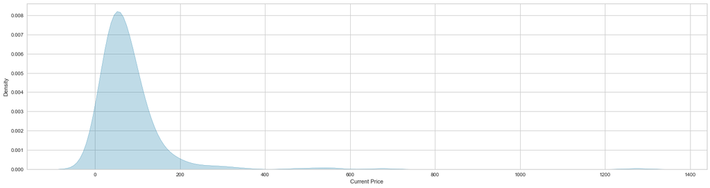

```python
plt.figure(figsize=(24, 6))
sns.kdeplot(data = stock_data, x = 'Current Price', shade = 'fill')
```

```
(0.0, 200.0)
```

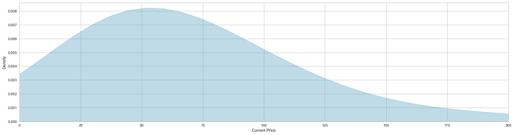

```python
plt.figure(figsize=(24, 6))
ax = sns.kdeplot(data = stock_data, x = 'Current Price', shade = 'fill')
ax.set_xlim([0, 200])
```

```python
stock_data['Current Price'].describe()
```

```
count     340.000000
mean       80.862345
std        98.055086
min         4.500000
25%        38.555000
50%        59.705000
75%        92.880001
max      1274.949951
Name: Current Price, dtype: float64
```

## Observation:

- The average stock price is \$80.86.
- The standard deviation of stock prices is \$98.
- The minimum stock price is \$4.50.
- The maximum stock price is \$1274.94.
- The top of the bell curve is at \$50.

## 2. The stocks of which economic sector have seen the maximum price increase on average?

```
(0.0, 200.0)
```

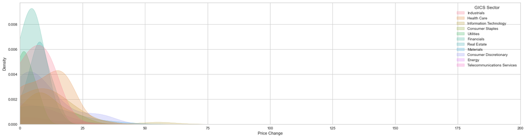

```python
plt.figure(figsize=(24, 6))
ax = sns.kdeplot(data = stock_data, x = 'Price Change', hue = 'GICS Sector', shade = 'fill')
ax.set_xlim([0, 200])
```

```
(0.0, 25.0)
```

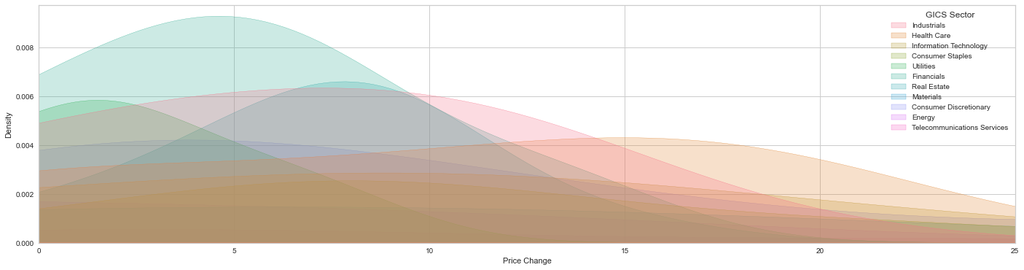

```python
plt.figure(figsize=(24, 6))
ax = sns.kdeplot(data = stock_data, x = 'Price Change', hue = 'GICS Sector', shade = 'fill')
ax.set_xlim([0, 25])
```

```
(25.0, 75.0)
```

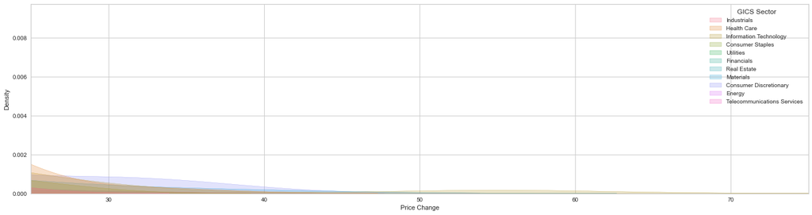

```python
plt.figure(figsize=(24, 6))
ax = sns.kdeplot(data = stock_data, x = 'Price Change', hue = 'GICS Sector', shade = 'fill')
ax.set_xlim([25, 75])
```

```python
stock_data.groupby(['GICS Sector'])['Price Change'].describe()
```

| GICS Sector | count | mean | std | min | 25% | 50% | 75% | max |
| --- | --- | --- | --- | --- | --- | --- | --- | --- |
| Consumer Discretionary | 40.0 | 5.846093 | 13.290771 | -33.131268 | 1.227730 | 3.543658 | 12.249013 | 34.803917 |
| Consumer Staples | 19.0 | 8.684750 | 8.795128 | -12.017268 | 5.426784 | 6.976738 | 12.605282 | 24.496225 |
| Energy | 30.0 | -10.228289 | 16.939222 | -47.129693 | -20.668060 | -9.244788 | 2.959008 | 17.341522 |
| Financials | 49.0 | 3.865406 | 6.024301 | -14.292764 | -0.361785 | 3.910301 | 7.696534 | 15.462833 |
| Health Care | 40.0 | 9.585652 | 9.848818 | -12.532337 | 1.528455 | 10.324402 | 16.775604 | 33.177346 |
| Industrials | 53.0 | 2.833127 | 9.922247 | -23.244191 | -2.797977 | 3.952561 | 10.105078 | 20.432767 |
| Information Technology | 33.0 | 7.217476 | 14.462923 | -23.790903 | -1.827858 | 7.496965 | 14.035095 | 55.051683 |
| Materials | 20.0 | 5.589738 | 15.283690 | -31.685166 | -1.306572 | 4.906245 | 15.450133 | 37.489677 |
| Real Estate | 27.0 | 6.205548 | 5.623694 | -13.067267 | 4.198144 | 7.578608 | 9.139503 | 15.573900 |
| Telecommunications Services | 5.0 | 6.956980 | 10.588878 | -2.301255 | 0.159232 | 5.942118 | 6.277303 | 24.707504 |
| Utilities | 24.0 | 0.803657 | 4.471067 | -8.230553 | -2.187929 | 1.281624 | 3.661202 | 8.596874 |

## 3. How are the different variables correlated with each other?

```python
correlation = stock_data.corr()
```

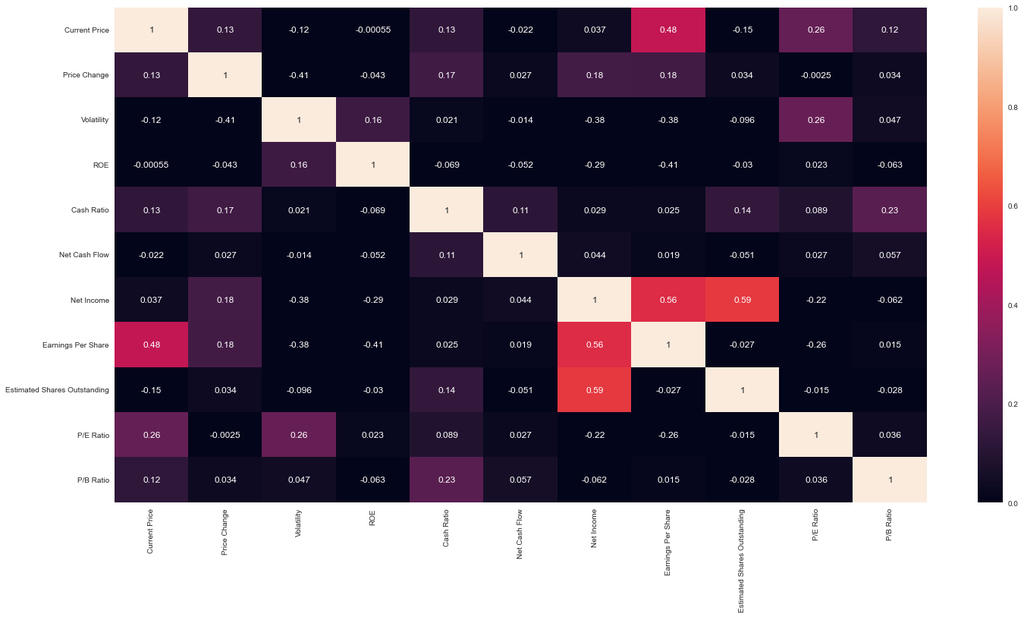

```python
plt.figure(figsize=(24, 12))
sns.heatmap(data = correlation, vmin = 0, vmax = 1, annot = True)
```

### Obervsations:

- Current Price and Earnings Per Share have a correlation of 0.48.
- Earnings Per Share and Net Income have a correlation of 0.56.
- Estimated Shares Outstanding and Net Income have a correlation of 0.59.
- However, Estimated Shares Outstanding and Earnings Per Share have a low degree of correlation.

## 4. Cash ratio provides a measure of a company's ability to cover its short-term obligations using only cash and cash equivalents. How does the average cash ratio vary across economic sectors?

```python
stock_data.groupby(['GICS Sector'])['Cash Ratio'].describe()
```

| GICS Sector | count | mean | std | min | 25% | 50% | 75% | max |
| --- | --- | --- | --- | --- | --- | --- | --- | --- |
| Consumer Discretionary | 40.0 | 49.575000 | 69.208302 | 0.0 | 11.5 | 25.0 | 35.50 | 260.0 |
| Consumer Staples | 19.0 | 70.947368 | 125.832549 | 9.0 | 18.0 | 33.0 | 63.00 | 568.0 |
| Energy | 30.0 | 51.133333 | 55.939458 | 0.0 | 7.0 | 38.5 | 68.50 | 201.0 |
| Financials | 49.0 | 98.591837 | 17.907073 | 51.0 | 99.0 | 99.0 | 99.00 | 183.0 |
| Health Care | 40.0 | 103.775000 | 104.118150 | 3.0 | 41.5 | 70.0 | 128.25 | 425.0 |
| Industrials | 53.0 | 36.188679 | 29.127080 | 1.0 | 15.0 | 31.0 | 44.00 | 130.0 |
| Information Technology | 33.0 | 149.818182 | 174.231429 | 16.0 | 45.0 | 126.0 | 180.00 | 958.0 |
| Materials | 20.0 | 41.700000 | 50.396428 | 2.0 | 10.0 | 25.0 | 49.50 | 198.0 |
| Real Estate | 27.0 | 50.111111 | 28.250709 | 12.0 | 47.0 | 47.0 | 47.00 | 164.0 |
| Telecommunications Services | 5.0 | 117.000000 | 213.083317 | 3.0 | 11.0 | 14.0 | 61.00 | 496.0 |
| Utilities | 24.0 | 13.625000 | 17.277310 | 0.0 | 3.0 | 8.5 | 14.25 | 74.0 |

### 5. P/E ratios can help determine the relative value of a company's shares as they signify the amount of money an investor is willing to invest in a single share of a company per dollar of its earnings. How does the P/E ratio vary, on average, across economic sectors?

```python
stock_data.groupby(['GICS Sector'])['P/E Ratio'].describe()
```

| GICS Sector | count | mean | std | min | 25% | 50% | 75% | max |
| --- | --- | --- | --- | --- | --- | --- | --- | --- |
| Consumer Discretionary | 40.0 | 35.211613 | 80.902902 | 5.566284 | 15.459391 | 20.819876 | 25.887634 | 528.039074 |
| Consumer Staples | 19.0 | 25.521195 | 10.291193 | 9.986637 | 21.391092 | 24.070121 | 26.176366 | 48.412370 |
| Energy | 30.0 | 72.897709 | 42.144306 | 8.429600 | 28.407929 | 93.089287 | 93.089287 | 171.962965 |
| Financials | 49.0 | 16.023151 | 7.281892 | 4.304511 | 10.914049 | 14.276451 | 18.703854 | 38.721154 |
| Health Care | 40.0 | 41.135272 | 46.756416 | 8.180275 | 19.165522 | 27.967442 | 35.700025 | 280.514706 |
| Industrials | 53.0 | 18.259380 | 7.587633 | 2.935451 | 13.048485 | 17.334711 | 20.556076 | 41.199999 |
| Information Technology | 33.0 | 43.782546 | 70.242260 | 10.209198 | 18.249407 | 25.309524 | 31.040405 | 394.413783 |
| Materials | 20.0 | 24.585352 | 12.349729 | 9.033264 | 16.001852 | 22.811951 | 32.226881 | 57.210844 |
| Real Estate | 27.0 | 43.065585 | 22.799372 | 13.164179 | 28.294875 | 33.685393 | 48.266787 | 110.764709 |
| Telecommunications Services | 5.0 | 12.222578 | 4.210623 | 5.598352 | 10.552512 | 14.518987 | 14.518987 | 15.924051 |
| Utilities | 24.0 | 18.719412 | 5.143485 | 9.293155 | 16.909186 | 18.216489 | 19.510019 | 33.792080 |

## Data Preprocessing

- Duplicate value check
- Missing value treatment
- Outlier check
- Feature engineering (if needed)
- Any other preprocessing steps (if needed)

```python
stock_data.isna().sum()
```

```
Ticker Symbol                   0
Security                        0
GICS Sector                     0
GICS Sub Industry               0
Current Price                   0
Price Change                    0
Volatility                      0
ROE                             0
Cash Ratio                      0
Net Cash Flow                   0
Net Income                      0
Earnings Per Share              0
Estimated Shares Outstanding    0
P/E Ratio                       0
P/B Ratio                       0
dtype: int64
```

### Observations

- There are no NaN values in the dataframe.

```python
stock_data[stock_data.duplicated()]
```

|  | Ticker Symbol | Security | GICS Sector | GICS Sub Industry | Current Price | Price Change | Volatility | ROE | Cash Ratio | Net Cash Flow | Net Income | Earnings Per Share | Estimated Shares Outstanding | P/E Ratio | P/B Ratio |
| --- | --- | --- | --- | --- | --- | --- | --- | --- | --- | --- | --- | --- | --- | --- | --- |

```python
stock_data[stock_data.duplicated(['Ticker Symbol'])]
```

|  | Ticker Symbol | Security | GICS Sector | GICS Sub Industry | Current Price | Price Change | Volatility | ROE | Cash Ratio | Net Cash Flow | Net Income | Earnings Per Share | Estimated Shares Outstanding | P/E Ratio | P/B Ratio |
| --- | --- | --- | --- | --- | --- | --- | --- | --- | --- | --- | --- | --- | --- | --- | --- |

### Observations

- There are no duplicated rows or ticker symbols

## Outlier Check

```python
stock_data_temp = stock_data.copy()
```

```python
stock_data = stock_data[(np.abs(stats.zscore(stock_data[[
    'Current Price',
    'Price Change',
    'Volatility',
    'ROE',
    'Cash Ratio',
    'Net Cash Flow',
    'Net Income',
    'Earnings Per Share',
    'Estimated Shares Outstanding',
    'P/E Ratio',
    'P/B Ratio'
]])) < 3)]
```

```python
stock_data['Ticker Symbol'] = stock_data_temp['Ticker Symbol']
stock_data['Security'] = stock_data_temp['Security']
stock_data['GICS Sector'] = stock_data_temp['GICS Sector']
stock_data['GICS Sub Industry'] = stock_data_temp['GICS Sub Industry']
```

```python
stock_data = stock_data.dropna()
```

## Feature Engineering

```python
stock_data['Ticker Symbol'] = stock_data['Ticker Symbol'].astype('category')
stock_data['Security'] = stock_data['Security'].astype('category')
stock_data['GICS Sector'] = stock_data['GICS Sector'].astype('category')
stock_data['GICS Sub Industry'] = stock_data['GICS Sub Industry'].astype('category')
```

```python
stock_data.info()
```

```
<class 'pandas.core.frame.DataFrame'>
Int64Index: 285 entries, 0 to 339
Data columns (total 15 columns):
 #   Column                        Non-Null Count  Dtype
---  ------                        --------------  -----
 0   Ticker Symbol                 285 non-null    category
 1   Security                      285 non-null    category
 2   GICS Sector                   285 non-null    category
 3   GICS Sub Industry             285 non-null    category
 4   Current Price                 285 non-null    float64
 5   Price Change                  285 non-null    float64
 6   Volatility                    285 non-null    float64
 7   ROE                           285 non-null    float64
 8   Cash Ratio                    285 non-null    float64
 9   Net Cash Flow                 285 non-null    float64
 10  Net Income                    285 non-null    float64
 11  Earnings Per Share            285 non-null    float64
 12  Estimated Shares Outstanding  285 non-null    float64
 13  P/E Ratio                     285 non-null    float64
 14  P/B Ratio                     285 non-null    float64
dtypes: category(4), float64(11)
memory usage: 56.5 KB
```

### Ticker Symbol

#### This is an ID column, so it can be dropped.

```python
stock_data['Ticker Symbol'].nunique() - len(stock_data)
```

```
0
```

```python
stock_data = stock_data.drop([
    'Ticker Symbol'
], axis = 1)
```

### Security

#### This is also a unique column, so it can be dropped.

```python
stock_data['Security'].nunique() - len(stock_data)
```

```
0
```

```python
stock_data = stock_data.drop([
    'Security'
], axis = 1)
```

### GICS Sector

```python
stock_data['GICS Sector'].nunique()
```

```
11
```

#### Perform one-hot encoding on the GICS Sector

```python
encoded = pd.get_dummies(stock_data['GICS Sector'], prefix = 'Sector')
```

```python
encoded
```

|  | Sector_Consumer Discretionary | Sector_Consumer Staples | Sector_Energy | Sector_Financials | Sector_Health Care | Sector_Industrials | Sector_Information Technology | Sector_Materials | Sector_Real Estate | Sector_Telecommunications Services | Sector_Utilities |
| --- | --- | --- | --- | --- | --- | --- | --- | --- | --- | --- | --- |
| 0 | 0 | 0 | 0 | 0 | 0 | 1 | 0 | 0 | 0 | 0 | 0 |
| 1 | 0 | 0 | 0 | 0 | 1 | 0 | 0 | 0 | 0 | 0 | 0 |
| 2 | 0 | 0 | 0 | 0 | 1 | 0 | 0 | 0 | 0 | 0 | 0 |
| 3 | 0 | 0 | 0 | 0 | 0 | 0 | 1 | 0 | 0 | 0 | 0 |
| 5 | 0 | 1 | 0 | 0 | 0 | 0 | 0 | 0 | 0 | 0 | 0 |
| ... | ... | ... | ... | ... | ... | ... | ... | ... | ... | ... | ... |
| 334 | 0 | 0 | 0 | 0 | 0 | 1 | 0 | 0 | 0 | 0 | 0 |
| 336 | 1 | 0 | 0 | 0 | 0 | 0 | 0 | 0 | 0 | 0 | 0 |
| 337 | 0 | 0 | 0 | 0 | 1 | 0 | 0 | 0 | 0 | 0 | 0 |
| 338 | 0 | 0 | 0 | 1 | 0 | 0 | 0 | 0 | 0 | 0 | 0 |
| 339 | 0 | 0 | 0 | 0 | 1 | 0 | 0 | 0 | 0 | 0 | 0 |

285 rows × 11 columns

```python
stock_data.drop([
    'GICS Sector'
], axis = 1, inplace = True)
```

```python
stock_data = stock_data.join(encoded)
```

```python
stock_data
```

|  | GICS Sub Industry | Current Price | Price Change | Volatility | ROE | Cash Ratio | Net Cash Flow | Net Income | Earnings Per Share | Estimated Shares Outstanding | ... | Sector_Consumer Staples | Sector_Energy | Sector_Financials | Sector_Health Care | Sector_Industrials | Sector_Information Technology | Sector_Materials | Sector_Real Estate | Sector_Telecommunications Services | Sector_Utilities |
| --- | --- | --- | --- | --- | --- | --- | --- | --- | --- | --- | --- | --- | --- | --- | --- | --- | --- | --- | --- | --- | --- |
| 0 | Airlines | 42.349998 | 9.999995 | 1.687151 | 135.0 | 51.0 | -604000000.0 | 7.610000e+09 | 11.39 | 6.681299e+08 | ... | 0 | 0 | 0 | 0 | 1 | 0 | 0 | 0 | 0 | 0 |
| 1 | Pharmaceuticals | 59.240002 | 8.339433 | 2.197887 | 130.0 | 77.0 | 51000000.0 | 5.144000e+09 | 3.15 | 1.633016e+09 | ... | 0 | 0 | 0 | 1 | 0 | 0 | 0 | 0 | 0 | 0 |
| 2 | Health Care Equipment | 44.910000 | 11.301121 | 1.273646 | 21.0 | 67.0 | 938000000.0 | 4.423000e+09 | 2.94 | 1.504422e+09 | ... | 0 | 0 | 0 | 1 | 0 | 0 | 0 | 0 | 0 | 0 |
| 3 | Application Software | 93.940002 | 13.977195 | 1.357679 | 9.0 | 180.0 | -240840000.0 | 6.295510e+08 | 1.26 | 4.996437e+08 | ... | 0 | 0 | 0 | 0 | 0 | 1 | 0 | 0 | 0 | 0 |
| 5 | Agricultural Products | 36.680000 | -12.017268 | 1.516493 | 10.0 | 49.0 | -189000000.0 | 1.849000e+09 | 2.99 | 6.183946e+08 | ... | 1 | 0 | 0 | 0 | 0 | 0 | 0 | 0 | 0 | 0 |
| ... | ... | ... | ... | ... | ... | ... | ... | ... | ... | ... | ... | ... | ... | ... | ... | ... | ... | ... | ... | ... | ... |
| 334 | Industrial Conglomerates | 36.500000 | 11.009729 | 1.166311 | 16.0 | 83.0 | 17000000.0 | 3.400000e+08 | 1.88 | 1.808511e+08 | ... | 0 | 0 | 0 | 0 | 1 | 0 | 0 | 0 | 0 | 0 |
| 336 | Restaurants | 52.516175 | -8.698917 | 1.478877 | 142.0 | 27.0 | 159000000.0 | 1.293000e+09 | 2.97 | 4.353535e+08 | ... | 0 | 0 | 0 | 0 | 0 | 0 | 0 | 0 | 0 | 0 |
| 337 | Health Care Equipment | 102.589996 | 9.347683 | 1.404206 | 1.0 | 100.0 | 376000000.0 | 1.470000e+08 | 0.78 | 1.884615e+08 | ... | 0 | 0 | 0 | 1 | 0 | 0 | 0 | 0 | 0 | 0 |
| 338 | Regional Banks | 27.299999 | -1.158588 | 1.468176 | 4.0 | 99.0 | -43623000.0 | 3.094710e+08 | 1.20 | 2.578925e+08 | ... | 0 | 0 | 1 | 0 | 0 | 0 | 0 | 0 | 0 | 0 |
| 339 | Pharmaceuticals | 47.919998 | 16.678836 | 1.610285 | 32.0 | 65.0 | 272000000.0 | 3.390000e+08 | 0.68 | 4.985294e+08 | ... | 0 | 0 | 0 | 1 | 0 | 0 | 0 | 0 | 0 | 0 |

285 rows × 23 columns

### GICS Sub Industry

```python
stock_data['GICS Sub Industry'].nunique()
```

```
98
```

#### This field contain too many unique values and should be dropped.

```python
stock_data.drop([
    'GICS Sub Industry'
], axis = 1, inplace = True)
```

### Current Price

```python
stock_data.info()
```

```
<class 'pandas.core.frame.DataFrame'>
Int64Index: 285 entries, 0 to 339
Data columns (total 22 columns):
 #   Column                              Non-Null Count  Dtype
---  ------                              --------------  -----
 0   Current Price                       285 non-null    float64
 1   Price Change                        285 non-null    float64
 2   Volatility                          285 non-null    float64
 3   ROE                                 285 non-null    float64
 4   Cash Ratio                          285 non-null    float64
 5   Net Cash Flow                       285 non-null    float64
 6   Net Income                          285 non-null    float64
 7   Earnings Per Share                  285 non-null    float64
 8   Estimated Shares Outstanding        285 non-null    float64
 9   P/E Ratio                           285 non-null    float64
 10  P/B Ratio                           285 non-null    float64
 11  Sector_Consumer Discretionary       285 non-null    uint8
 12  Sector_Consumer Staples             285 non-null    uint8
 13  Sector_Energy                       285 non-null    uint8
 14  Sector_Financials                   285 non-null    uint8
 15  Sector_Health Care                  285 non-null    uint8
 16  Sector_Industrials                  285 non-null    uint8
 17  Sector_Information Technology       285 non-null    uint8
 18  Sector_Materials                    285 non-null    uint8
 19  Sector_Real Estate                  285 non-null    uint8
 20  Sector_Telecommunications Services  285 non-null    uint8
 21  Sector_Utilities                    285 non-null    uint8
dtypes: float64(11), uint8(11)
memory usage: 39.8 KB
```

```python
stock_data['Current Price'].describe()
```

```
count    285.000000
mean      72.541979
std       49.797961
min        7.398807
25%       40.810001
50%       59.900002
75%       90.809998
max      339.130005
Name: Current Price, dtype: float64
```

```python
stock_data['Current Price'] -= np.min(stock_data['Current Price'])
stock_data['Current Price'] /= np.max(stock_data['Current Price'])
```

```python
stock_data['Current Price'].describe()
```

```
count    285.000000
mean       0.196373
std        0.150115
min        0.000000
25%        0.100718
50%        0.158264
75%        0.251442
max        1.000000
Name: Current Price, dtype: float64
```

```python
stock_data['Current Price'] = np.power(stock_data['Current Price'], 1/3)
```

### Price Change

```python
stock_data['Price Change'].describe()
```

```
count    285.000000
mean       4.746271
std        9.875038
min      -23.790903
25%       -0.463767
50%        4.917982
75%       10.328820
max       37.489677
Name: Price Change, dtype: float64
```

```python
stock_data['Price Change'] -= np.min(stock_data['Price Change'])
stock_data['Price Change'] /= np.max(stock_data['Price Change'])
```

```python
stock_data['Price Change'].describe()
```

```
count    285.000000
mean       0.465681
std        0.161145
min        0.000000
25%        0.380661
50%        0.468483
75%        0.556779
max        1.000000
Name: Price Change, dtype: float64
```

### Volatility

```python
stock_data['Volatility'].describe()
```

```
count    285.000000
mean       1.433021
std        0.418267
min        0.733163
25%        1.131240
50%        1.351595
75%        1.588398
max        3.055818
Name: Volatility, dtype: float64
```

```python
stock_data['Volatility'] -= np.min(stock_data['Volatility'])
stock_data['Volatility'] /= np.max(stock_data['Volatility'])
```

```python
stock_data['Volatility'].describe()
```

```
count    285.000000
mean       0.301318
std        0.180081
min        0.000000
25%        0.171389
50%        0.266261
75%        0.368214
max        1.000000
Name: Volatility, dtype: float64
```

```python
stock_data['Volatility'] = np.power(stock_data['Volatility'], 1/2)
```

```python
stock_data['Volatility'].describe()
```

```
count    285.000000
mean       0.525704
std        0.158244
min        0.000000
25%        0.413991
50%        0.516004
75%        0.606807
max        1.000000
Name: Volatility, dtype: float64
```

### ROE

```python
stock_data['ROE'].describe()
```

```
count    285.000000
mean      24.985965
std       34.783938
min        1.000000
25%       10.000000
50%       15.000000
75%       25.000000
max      263.000000
Name: ROE, dtype: float64
```

```python
stock_data['ROE'] -= np.min(stock_data['ROE'])
stock_data['ROE'] /= np.max(stock_data['ROE'])
```

```python
stock_data['ROE'].describe()
```

```
count    285.000000
mean       0.091549
std        0.132763
min        0.000000
25%        0.034351
50%        0.053435
75%        0.091603
max        1.000000
Name: ROE, dtype: float64
```

```python
stock_data['ROE'] = np.power(stock_data['ROE'], 1/4)
```

```python
stock_data['ROE'].describe()
```

```
count    285.000000
mean       0.497636
std        0.128947
min        0.000000
25%        0.430512
50%        0.480791
75%        0.550145
max        1.000000
Name: ROE, dtype: float64
```

### Cash Ratio

```python
stock_data['Cash Ratio'].describe()
```

```
count    285.000000
mean      58.466667
std       54.438974
min        0.000000
25%       18.000000
50%       44.000000
75%       99.000000
max      333.000000
Name: Cash Ratio, dtype: float64
```

```python
stock_data['Cash Ratio'] -= np.min(stock_data['Cash Ratio'])
stock_data['Cash Ratio'] /= np.max(stock_data['Cash Ratio'])
```

```python
stock_data['Cash Ratio'].describe()
```

```
count    285.000000
mean       0.175576
std        0.163480
min        0.000000
25%        0.054054
50%        0.132132
75%        0.297297
max        1.000000
Name: Cash Ratio, dtype: float64
```

```python
stock_data['Cash Ratio'] = np.power(stock_data['Cash Ratio'], 1/3)
```

```python
stock_data['Cash Ratio'].describe()
```

```
count    285.000000
mean       0.503981
std        0.177793
min        0.000000
25%        0.378102
50%        0.509334
75%        0.667417
max        1.000000
Name: Cash Ratio, dtype: float64
```

### Net Cash Flow

```python
stock_data['Net Cash Flow'].describe()
```

```
count    2.850000e+02
mean     8.357593e+06
std      9.466007e+08
min     -4.496000e+09
25%     -1.890000e+08
50%      2.196000e+06
75%      1.590000e+08
max      5.607600e+09
Name: Net Cash Flow, dtype: float64
```

```python
stock_data['Net Cash Flow'] -= np.min(stock_data['Net Cash Flow'])
stock_data['Net Cash Flow'] /= np.max(stock_data['Net Cash Flow'])
```

```python
stock_data['Net Cash Flow'].describe()
```

```
count    285.000000
mean       0.445817
std        0.093689
min        0.000000
25%        0.426284
50%        0.445207
75%        0.460727
max        1.000000
Name: Net Cash Flow, dtype: float64
```

### Net Income

```python
stock_data['Net Income'].describe()
```

```
count    2.850000e+02
mean     1.366663e+09
std      1.989864e+09
min     -7.829000e+09
25%      3.694160e+08
50%      7.460000e+08
75%      1.757000e+09
max      1.319000e+10
Name: Net Income, dtype: float64
```

```python
stock_data['Net Income'] -= np.min(stock_data['Net Income'])
stock_data['Net Income'] /= np.max(stock_data['Net Income'])
```

```python
stock_data['Net Income'].describe()
```

```
count    285.000000
mean       0.437493
std        0.094670
min        0.000000
25%        0.390048
50%        0.407964
75%        0.456064
max        1.000000
Name: Net Income, dtype: float64
```

### Earnings Per Share

```python
stock_data['Earnings Per Share'].describe()
```

```
count    285.000000
mean       3.343561
std        3.428005
min      -13.030000
25%        1.730000
50%        3.010000
75%        4.650000
max       19.520000
Name: Earnings Per Share, dtype: float64
```

```python
stock_data['Earnings Per Share'] -= np.min(stock_data['Earnings Per Share'])
stock_data['Earnings Per Share'] /= np.max(stock_data['Earnings Per Share'])
```

```python
stock_data['Earnings Per Share'].describe()
```

```
count    285.000000
mean       0.503028
std        0.105315
min        0.000000
25%        0.453456
50%        0.492780
75%        0.543164
max        1.000000
Name: Earnings Per Share, dtype: float64
```

### Estimated Shares Outstanding

```python
stock_data['Estimated Shares Outstanding'].describe()
```

```
count    2.850000e+02
mean     4.402632e+08
std      4.224009e+08
min      2.767216e+07
25%      1.638243e+08
50%      2.931532e+08
75%      5.312292e+08
max      2.811392e+09
Name: Estimated Shares Outstanding, dtype: float64
```

```python
stock_data['Estimated Shares Outstanding'] -= np.min(stock_data['Estimated Shares Outstanding'])
stock_data['Estimated Shares Outstanding'] /= np.max(stock_data['Estimated Shares Outstanding'])
```

```python
stock_data['Estimated Shares Outstanding'].describe()
```

```
count    285.000000
mean       0.148216
std        0.151740
min        0.000000
25%        0.048910
50%        0.095369
75%        0.180894
max        1.000000
Name: Estimated Shares Outstanding, dtype: float64
```

```python
stock_data['Estimated Shares Outstanding'] = np.power(stock_data['Estimated Shares Outstanding'], 1/3)
```

```python
stock_data['Estimated Shares Outstanding'].describe()
```

```
count    285.000000
mean       0.481250
std        0.154777
min        0.000000
25%        0.365707
50%        0.456880
75%        0.565554
max        1.000000
Name: Estimated Shares Outstanding, dtype: float64
```

### P/E Ratio

```python
stock_data['P/E Ratio'].describe()
```

```
count    285.000000
mean      26.162855
std       20.008510
min        2.935451
25%       14.842233
50%       19.470720
75%       28.976191
max      131.525636
Name: P/E Ratio, dtype: float64
```

```python
stock_data['P/E Ratio'] -= np.min(stock_data['P/E Ratio'])
stock_data['P/E Ratio'] /= np.max(stock_data['P/E Ratio'])
```

```python
stock_data['P/E Ratio'].describe()
```

```
count    285.000000
mean       0.180631
std        0.155599
min        0.000000
25%        0.092595
50%        0.128589
75%        0.202510
max        1.000000
Name: P/E Ratio, dtype: float64
```

```python
stock_data['P/E Ratio'] = np.power(stock_data['P/E Ratio'], 1/3)
```

```python
stock_data['P/E Ratio'].describe()
```

```
count    285.000000
mean       0.532147
std        0.133073
min        0.000000
25%        0.452407
50%        0.504740
75%        0.587239
max        1.000000
Name: P/E Ratio, dtype: float64
```

### P/B Ratio

```python
stock_data['P/B Ratio'].describe()
```

```
count    285.000000
mean      -1.600206
std        7.869396
min      -31.015380
25%       -4.327138
50%       -1.269332
75%        3.345102
max       23.856728
Name: P/B Ratio, dtype: float64
```

```python
stock_data['P/B Ratio'] -= np.min(stock_data['P/B Ratio'])
stock_data['P/B Ratio'] /= np.max(stock_data['P/B Ratio'])
```

```python
stock_data['P/B Ratio'].describe()
```

```
count    285.000000
mean       0.536068
std        0.143413
min        0.000000
25%        0.486372
50%        0.542098
75%        0.626192
max        1.000000
Name: P/B Ratio, dtype: float64
```

```python
stock_data.describe()
```

|  | Current Price | Price Change | Volatility | ROE | Cash Ratio | Net Cash Flow | Net Income | Earnings Per Share | Estimated Shares Outstanding | P/E Ratio | ... | Sector_Consumer Staples | Sector_Energy | Sector_Financials | Sector_Health Care | Sector_Industrials | Sector_Information Technology | Sector_Materials | Sector_Real Estate | Sector_Telecommunications Services | Sector_Utilities |
| --- | --- | --- | --- | --- | --- | --- | --- | --- | --- | --- | --- | --- | --- | --- | --- | --- | --- | --- | --- | --- | --- |
| count | 285.000000 | 285.000000 | 285.000000 | 285.000000 | 285.000000 | 285.000000 | 285.000000 | 285.000000 | 285.000000 | 285.000000 | ... | 285.000000 | 285.000000 | 285.000000 | 285.000000 | 285.000000 | 285.000000 | 285.000000 | 285.000000 | 285.000000 | 285.000000 |
| mean | 0.548495 | 0.465681 | 0.525704 | 0.497636 | 0.503981 | 0.445817 | 0.437493 | 0.503028 | 0.481250 | 0.532147 | ... | 0.052632 | 0.052632 | 0.150877 | 0.115789 | 0.182456 | 0.087719 | 0.066667 | 0.094737 | 0.007018 | 0.084211 |
| std | 0.137380 | 0.161145 | 0.158244 | 0.128947 | 0.177793 | 0.093689 | 0.094670 | 0.105315 | 0.154777 | 0.133073 | ... | 0.223690 | 0.223690 | 0.358559 | 0.320535 | 0.386899 | 0.283384 | 0.249883 | 0.293366 | 0.083623 | 0.278192 |
| min | 0.000000 | 0.000000 | 0.000000 | 0.000000 | 0.000000 | 0.000000 | 0.000000 | 0.000000 | 0.000000 | 0.000000 | ... | 0.000000 | 0.000000 | 0.000000 | 0.000000 | 0.000000 | 0.000000 | 0.000000 | 0.000000 | 0.000000 | 0.000000 |
| 25% | 0.465267 | 0.380661 | 0.413991 | 0.430512 | 0.378102 | 0.426284 | 0.390048 | 0.453456 | 0.365707 | 0.452407 | ... | 0.000000 | 0.000000 | 0.000000 | 0.000000 | 0.000000 | 0.000000 | 0.000000 | 0.000000 | 0.000000 | 0.000000 |
| 50% | 0.540913 | 0.468483 | 0.516004 | 0.480791 | 0.509334 | 0.445207 | 0.407964 | 0.492780 | 0.456880 | 0.504740 | ... | 0.000000 | 0.000000 | 0.000000 | 0.000000 | 0.000000 | 0.000000 | 0.000000 | 0.000000 | 0.000000 | 0.000000 |
| 75% | 0.631169 | 0.556779 | 0.606807 | 0.550145 | 0.667417 | 0.460727 | 0.456064 | 0.543164 | 0.565554 | 0.587239 | ... | 0.000000 | 0.000000 | 0.000000 | 0.000000 | 0.000000 | 0.000000 | 0.000000 | 0.000000 | 0.000000 | 0.000000 |
| max | 1.000000 | 1.000000 | 1.000000 | 1.000000 | 1.000000 | 1.000000 | 1.000000 | 1.000000 | 1.000000 | 1.000000 | ... | 1.000000 | 1.000000 | 1.000000 | 1.000000 | 1.000000 | 1.000000 | 1.000000 | 1.000000 | 1.000000 | 1.000000 |

8 rows × 22 columns

## EDA

- It is a good idea to explore the data once again after manipulating it.

```python
def histogram_boxplot(data, feature, figsize=(12, 7), kde=False, bins=None):
    """
    Boxplot and histogram combined

    data: dataframe
    feature: dataframe column
    figsize: size of figure (default (12,7))
    kde: whether to the show density curve (default False)
    bins: number of bins for histogram (default None)
    """
    f2, (ax_box2, ax_hist2) = plt.subplots(
        nrows=2,  # Number of rows of the subplot grid= 2
        sharex=True,  # x-axis will be shared among all subplots
        gridspec_kw={"height_ratios": (0.25, 0.75)},
        figsize=figsize,
    )  # creating the 2 subplots
    sns.boxplot(
        data=data, x=feature, ax=ax_box2, showmeans=True, color="violet"
    )  # boxplot will be created and a star will indicate the mean value of the column
    sns.histplot(
        data=data, x=feature, kde=kde, ax=ax_hist2, bins=bins, palette="winter"
    ) if bins else sns.histplot(
        data=data, x=feature, kde=kde, ax=ax_hist2
    )  # For histogram
    ax_hist2.axvline(
        data[feature].mean(), color="green", linestyle="--"
    )  # Add mean to the histogram
    ax_hist2.axvline(
        data[feature].median(), color="black", linestyle="-"
    )  # Add median to the histogram
```

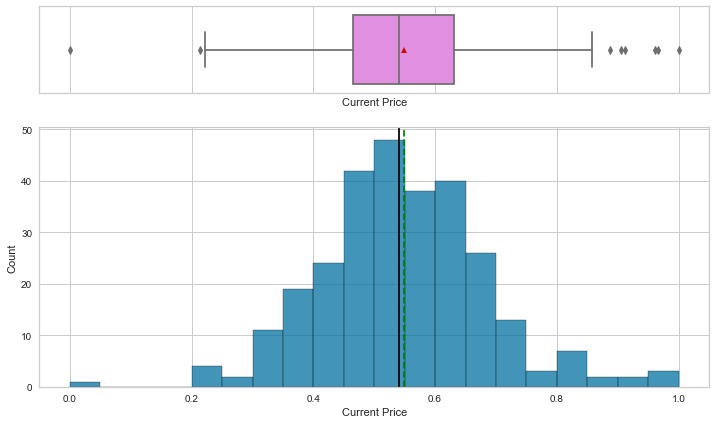

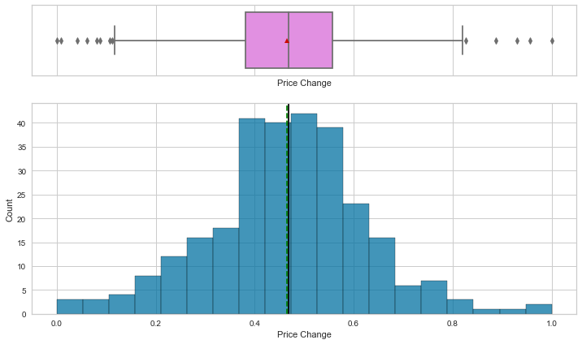

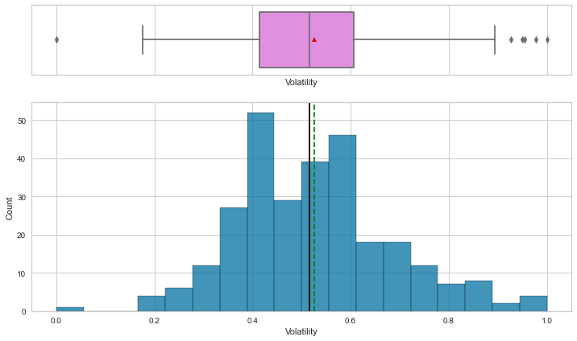

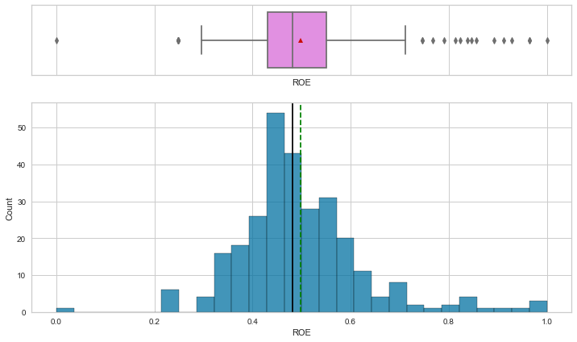

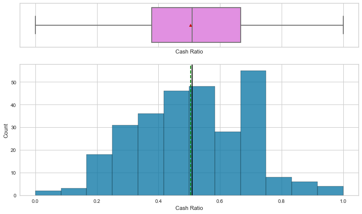

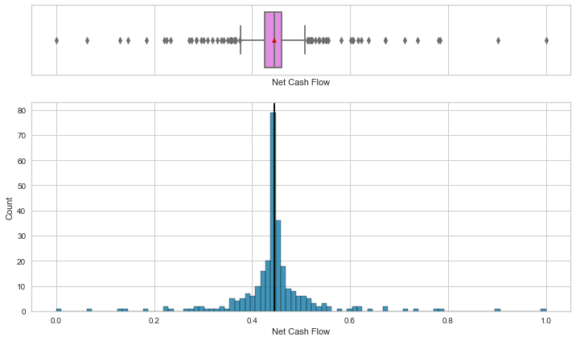

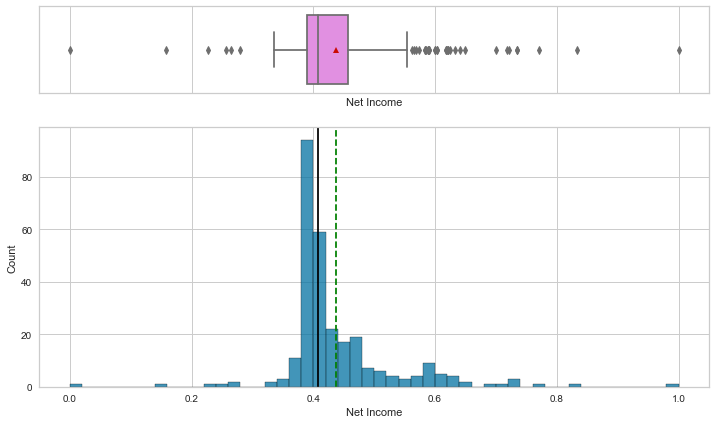

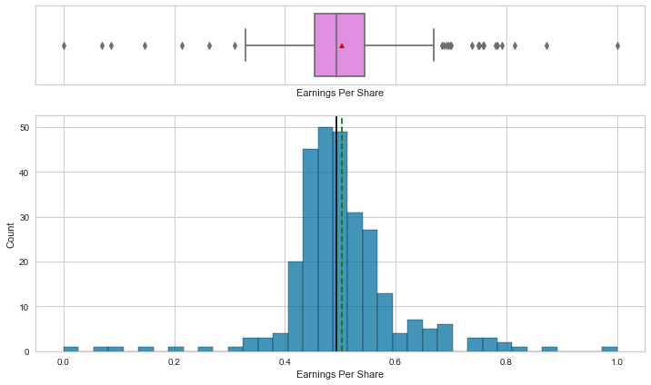

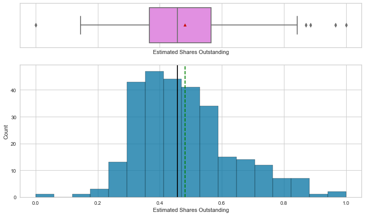

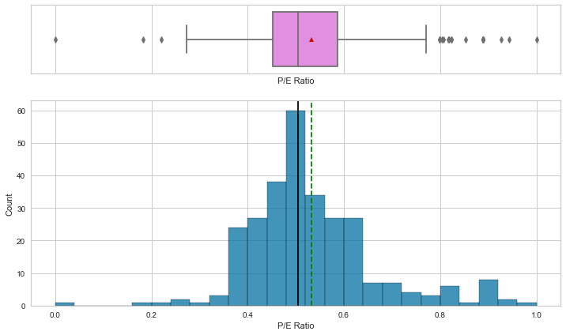

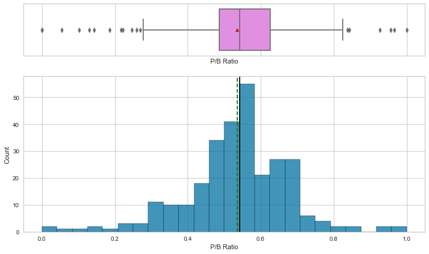

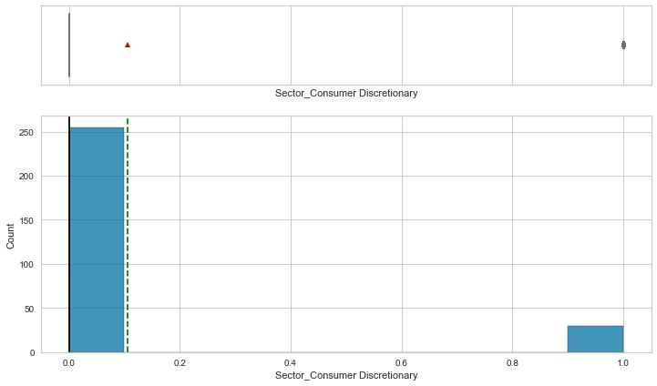

[10 more figures not shown]

```python
# selecting numerical columns
num_col = stock_data.select_dtypes(include=np.number).columns.tolist()

for item in num_col:
    histogram_boxplot(stock_data, item)
```

### Observations

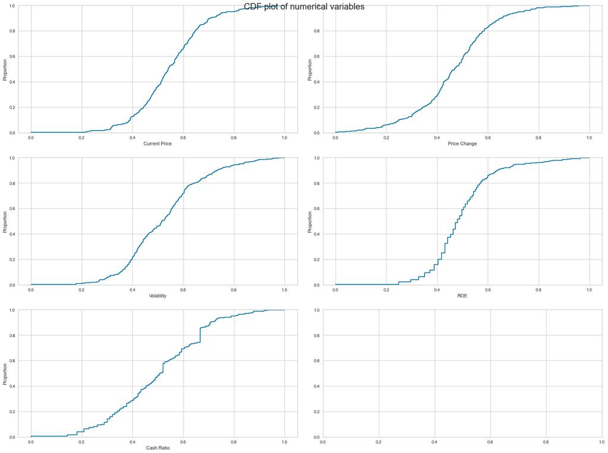

```python
fig, axes = plt.subplots(3, 2, figsize=(20, 15))
fig.suptitle("CDF plot of numerical variables", fontsize=20)
counter = 0
for ii in range(3):
    sns.ecdfplot(ax=axes[ii][0], x=stock_data[num_col[counter]])
    counter = counter + 1
    if counter != 5:
        sns.ecdfplot(ax=axes[ii][1], x=stock_data[num_col[counter]])
        counter = counter + 1
    else:
        pass

fig.tight_layout(pad=2.0)
```

```python
def labeled_barplot(data, feature, perc=False, n=None):
    """
    Barplot with percentage at the top

    data: dataframe
    feature: dataframe column
    perc: whether to display percentages instead of count (default is False)
    n: displays the top n category levels (default is None, i.e., display all levels)
    """

    total = len(data[feature])  # length of the column
    count = data[feature].nunique()
    if n is None:
        plt.figure(figsize=(count + 1, 5))
    else:
        plt.figure(figsize=(n + 1, 5))

    plt.xticks(rotation=90, fontsize=15)
    ax = sns.countplot(
        data=data,
        x=feature,
        palette="Paired",
        order=data[feature].value_counts().index[:n].sort_values(),
    )

    for p in ax.patches:
        if perc:
            label = "{:.1f}%".format(
                100 * p.get_height() / total
            )  # percentage of each class of the category
        else:
            label = p.get_height()  # count of each level of the category

        x = p.get_x() + p.get_width() / 2  # width of the plot
        y = p.get_height()  # height of the plot

        ax.annotate(
            label,
            (x, y),
            ha="center",
            va="center",
            size=12,
            xytext=(0, 5),
            textcoords="offset points",
        )  # annotate the percentage

    plt.show()  # show the plot
```

```python
stock_data.info()
```

```
<class 'pandas.core.frame.DataFrame'>
Int64Index: 285 entries, 0 to 339
Data columns (total 22 columns):
 #   Column                              Non-Null Count  Dtype
---  ------                              --------------  -----
 0   Current Price                       285 non-null    float64
 1   Price Change                        285 non-null    float64
 2   Volatility                          285 non-null    float64
 3   ROE                                 285 non-null    float64
 4   Cash Ratio                          285 non-null    float64
 5   Net Cash Flow                       285 non-null    float64
 6   Net Income                          285 non-null    float64
 7   Earnings Per Share                  285 non-null    float64
 8   Estimated Shares Outstanding        285 non-null    float64
 9   P/E Ratio                           285 non-null    float64
 10  P/B Ratio                           285 non-null    float64
 11  Sector_Consumer Discretionary       285 non-null    uint8
 12  Sector_Consumer Staples             285 non-null    uint8
 13  Sector_Energy                       285 non-null    uint8
 14  Sector_Financials                   285 non-null    uint8
 15  Sector_Health Care                  285 non-null    uint8
 16  Sector_Industrials                  285 non-null    uint8
 17  Sector_Information Technology       285 non-null    uint8
 18  Sector_Materials                    285 non-null    uint8
 19  Sector_Real Estate                  285 non-null    uint8
 20  Sector_Telecommunications Services  285 non-null    uint8
 21  Sector_Utilities                    285 non-null    uint8
dtypes: float64(11), uint8(11)
memory usage: 39.8 KB
```

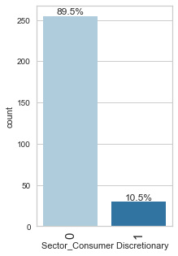

```python
labeled_barplot(stock_data, 'Sector_Consumer Discretionary', perc=True)
```

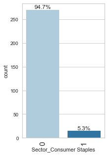

```python
labeled_barplot(stock_data, 'Sector_Consumer Staples', perc=True)
```

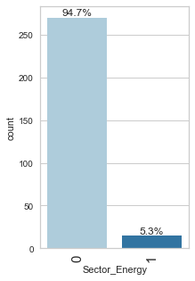

```python
labeled_barplot(stock_data, 'Sector_Energy', perc=True)
```

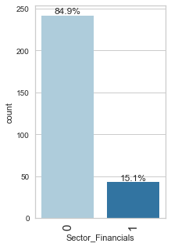

```python
labeled_barplot(stock_data, 'Sector_Financials', perc=True)
```

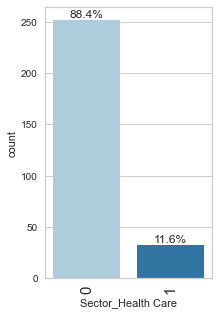

```python
labeled_barplot(stock_data, 'Sector_Health Care', perc=True)
```

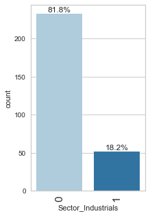

```python
labeled_barplot(stock_data, 'Sector_Industrials', perc=True)
```

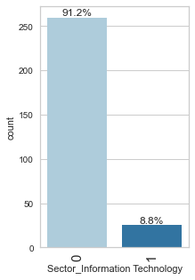

```python
labeled_barplot(stock_data, 'Sector_Information Technology', perc=True)
```

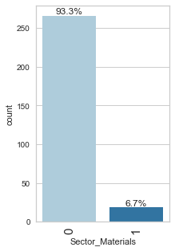

```python
labeled_barplot(stock_data, 'Sector_Materials', perc=True)
```

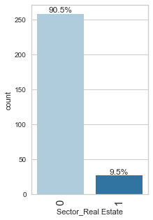

```python
labeled_barplot(stock_data, 'Sector_Real Estate', perc=True)
```

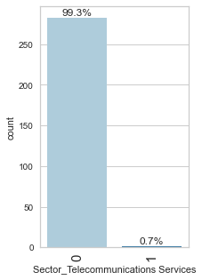

```python
labeled_barplot(stock_data, 'Sector_Telecommunications Services', perc=True)
```

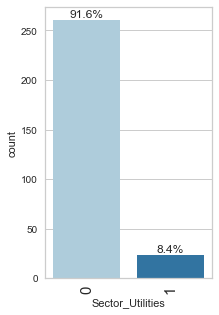

```python
labeled_barplot(stock_data, 'Sector_Utilities', perc=True)
```

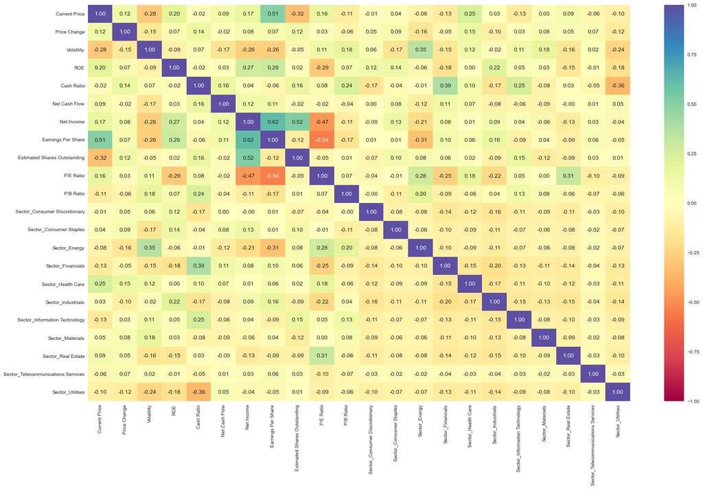

```python
plt.figure(figsize=(25, 15))
sns.heatmap(stock_data[num_col].corr(), annot=True, vmin=-1, vmax=1, fmt=".2f", cmap="Spectral")
plt.show()
```